# Model comparison (macro level)

Room popularity, Edge-load. Real tracks vs simulated (Unity).

**Input:** DXF with floor plan and zones, folder with real-trajectory CSVs, Simulation layer.

### Simulation parameters (Unity)

- 51 agents, start interval 2-6 s, 4 types: active explorer 15%, fast 30%, researcher 30%, slow 25%

```python
import sys
from pathlib import Path

# So that room_popularity import works when run from model_search or repo root
for d in [Path.cwd(), Path.cwd() / "model_search"]:
    if (d / "room_popularity.py").exists() and str(d) not in sys.path:
        sys.path.insert(0, str(d))
        break

# DXF: in this folder or model_search/ when run from root
PATH_DXF = str(Path("model_search") / "Floor_0.dxf") if (Path.cwd() / "model_search" / "Floor_0.dxf").exists() else "Floor_0.dxf"
PATH_TRAJECTORIES_CSV = "C://Users/malko/Desktop/Diploma/Term/bird-dataset-main/bird-dataset-main/data/normalized_trajectories"
LAYER_FLOOR_PLAN = "Floor_plan"
LAYER_AREA = "Area"
PATH_UNITY_DXF = str(Path("model_search") / "unity_plan_and_tracks.dxf") if (Path.cwd() / "model_search" / "unity_plan_and_tracks.dxf").exists() else "unity_plan_and_tracks.dxf"
LAYER_UNITY_TRACKS = "TRACKS"  # simulation tracks in unity DXF

from macro_compare import run_room_popularity_comparison, run_edge_load_comparison, run_global_summary_macro
from macro_data import load_tracks_and_plot, load_edge_load_real, load_edge_load_sim
```

```python
%pip install -q ezdxf pandas shapely matplotlib scipy
```

### Tracks: real and simulated (with floor plan)

Below: two visualizations — real tracks from the dataset and simulated tracks from Unity. Both overlaid on the DXF floor plan.

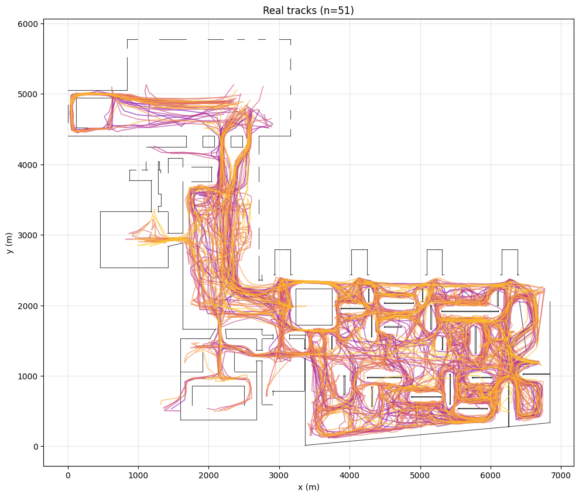

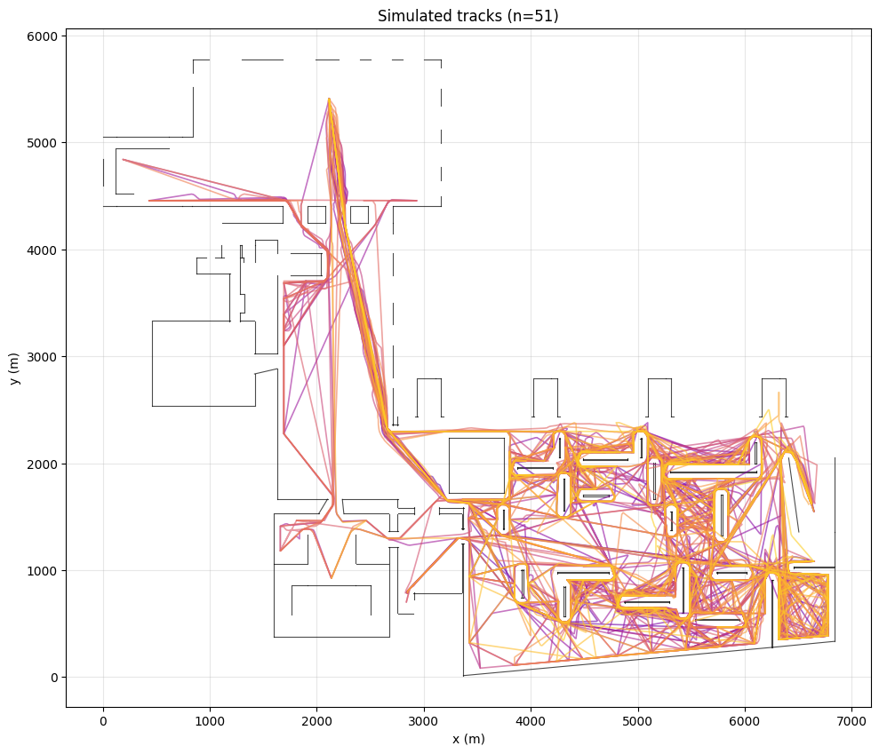

```python
plan_segments, traj_real, traj_sim = load_tracks_and_plot(
    PATH_DXF, LAYER_FLOOR_PLAN, PATH_TRAJECTORIES_CSV, PATH_UNITY_DXF, LAYER_UNITY_TRACKS
)
```

## Room popularity ranking (real)

Count: how many unique agents visited each zone. Chain from least to most popular (zone | n_agents_visited | rank).

```python
import importlib
import room_popularity
importlib.reload(room_popularity)
from room_popularity import compute_room_popularity_ranking, load_trajectories_from_csv

# Room popularity (real) — tracks from CSV
traj_real = load_trajectories_from_csv(PATH_TRAJECTORIES_CSV, floor_number=0)
df_real, chain_real, n_traj_real = compute_room_popularity_ranking(
    PATH_DXF, LAYER_AREA, trajectories=traj_real
)
print("Room popularity (real), n_trajectories:", n_traj_real)
display(df_real)
print("Chain:", ", ".join(map(str, chain_real)))
```

```
Room popularity (real), n_trajectories: 51
```

|  | zone | n_agents_visited | rank |
| --- | --- | --- | --- |
| 0 | 4 | 12 | 1 |
| 1 | 2 | 20 | 2 |
| 2 | 6 | 31 | 3 |
| 3 | 14 | 33 | 4 |
| 4 | 11 | 41 | 5 |
| 5 | 1 | 42 | 6 |
| 6 | 12 | 43 | 7 |
| 7 | 9 | 45 | 8 |
| 8 | 8 | 47 | 9 |
| 9 | 15 | 47 | 10 |
| 10 | 7 | 48 | 11 |
| 11 | 10 | 49 | 12 |
| 12 | 13 | 49 | 13 |
| 13 | 0 | 51 | 14 |
| 14 | 3 | 51 | 15 |
| 15 | 5 | 51 | 16 |

```
Chain: 4, 2, 6, 14, 11, 1, 12, 9, 8, 15, 7, 10, 13, 0, 3, 5
```

```python
from room_popularity import save_ranking

out_csv, out_json = save_ranking(
    df_real, chain_real, PATH_DXF, n_traj_real,
    layer_floor_plan=LAYER_FLOOR_PLAN,
    layer_area=LAYER_AREA,
    layer_trajectories="csv",
)
print(f"Saved: {out_csv}, {out_json}")
```

```
Saved: C:\Users\malko\Desktop\Diploma\Term\bird-dataset-main\model_search\room_popularity_ranking.csv, C:\Users\malko\Desktop\Diploma\Term\bird-dataset-main\model_search\room_popularity_ranking.json
```

## Room popularity ranking (simulated)

Same for simulated tracks (Simulation layer). Comparison with real shows how well simulation matches zone popularity.

```python
df_sim, chain_sim, n_traj_sim = compute_room_popularity_ranking(
    PATH_DXF, LAYER_AREA, trajectories=traj_sim
)
if n_traj_sim == 0:
    print("No simulated tracks (unity DXF layer TRACKS empty or file missing).")
else:
    print("Room popularity (simulated), n_trajectories:", n_traj_sim)
    display(df_sim)
    print("Chain:", ", ".join(map(str, chain_sim)))
```

```
Room popularity (simulated), n_trajectories: 51
```

|  | zone | n_agents_visited | rank |
| --- | --- | --- | --- |
| 0 | 1 | 5 | 1 |
| 1 | 2 | 7 | 2 |
| 2 | 6 | 19 | 3 |
| 3 | 8 | 30 | 4 |
| 4 | 14 | 37 | 5 |
| 5 | 11 | 38 | 6 |
| 6 | 9 | 43 | 7 |
| 7 | 12 | 43 | 8 |
| 8 | 15 | 46 | 9 |
| 9 | 10 | 49 | 10 |
| 10 | 13 | 49 | 11 |
| 11 | 7 | 50 | 12 |
| 12 | 0 | 51 | 13 |
| 13 | 3 | 51 | 14 |
| 14 | 5 | 51 | 15 |

```
Chain: 1, 2, 6, 8, 14, 11, 9, 12, 15, 10, 13, 7, 0, 3, 5
```

## Room popularity comparison

Scatter plot (n_agents real vs sim), basic stats (Pearson and Spearman correlation), slopegraph (connects same zones between real and sim rankings).

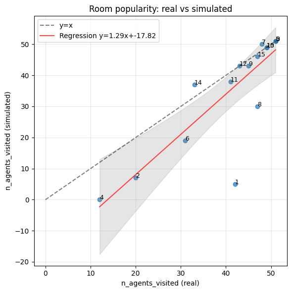

```
n_real: mean=43.2, std=8.9
n_sim:  mean=37.9, std=15.8
Pearson correlation (n_agents): r=0.765, p=0.0009
Spearman correlation (rank):     r=0.907, p=0.0000
```

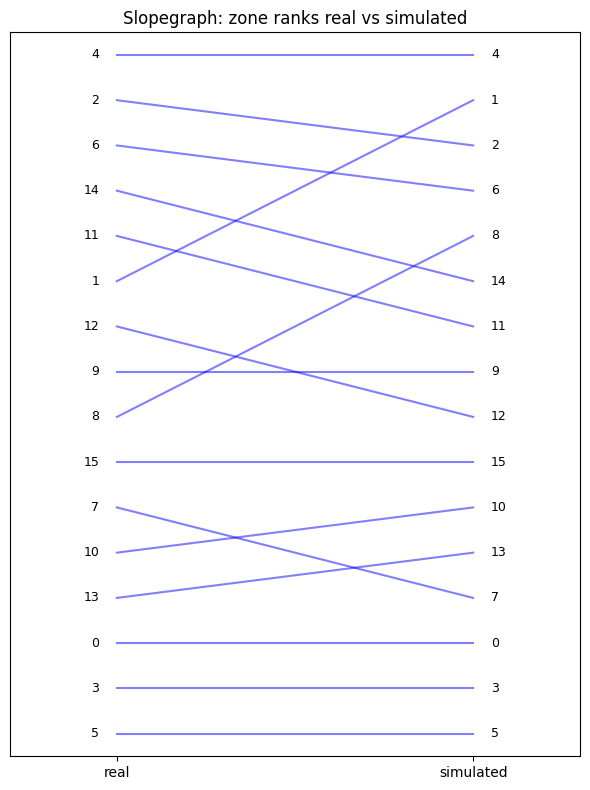

|  | zone | n_real | rank_real | rank_sim | n_sim |
| --- | --- | --- | --- | --- | --- |
| 0 | 0 | 51 | 14 | 13 | 51 |
| 1 | 1 | 42 | 6 | 1 | 5 |
| 2 | 2 | 20 | 2 | 2 | 7 |
| 3 | 3 | 51 | 15 | 14 | 51 |
| 4 | 4 | 12 | 1 | 0 | 0 |
| 5 | 5 | 51 | 16 | 15 | 51 |
| 6 | 6 | 31 | 3 | 3 | 19 |
| 7 | 7 | 48 | 11 | 12 | 50 |
| 8 | 8 | 47 | 9 | 4 | 30 |
| 9 | 9 | 45 | 8 | 7 | 43 |
| 10 | 10 | 49 | 12 | 10 | 49 |
| 11 | 11 | 41 | 5 | 6 | 38 |
| 12 | 12 | 43 | 7 | 8 | 43 |
| 13 | 13 | 49 | 13 | 11 | 49 |
| 14 | 14 | 33 | 4 | 5 | 37 |
| 15 | 15 | 47 | 10 | 9 | 46 |

```python
run_room_popularity_comparison(df_real, df_sim, n_traj_sim)
```

## Edge-load (real)

Transition popularity between zones: for each (from_zone, to_zone) — share of transitions (dependency_pct). Shows which passages agents use most.

```
Edge-load (real), total transitions: 1197
n_edges (unique transitions): 65
dependency_pct: min=0.08, max=4.34, mean=1.54, median=1.17, std=1.24
count: min=1, max=52, mean=18.42, median=14.00, std=14.82
```

|  | from_zone | to_zone | count | dependency | dependency_pct |
| --- | --- | --- | --- | --- | --- |
| 0 | 0 | 1 | 14 | 0.011696 | 1.17 |
| 1 | 0 | 5 | 42 | 0.035088 | 3.51 |
| 2 | 1 | 0 | 28 | 0.023392 | 2.34 |
| 3 | 1 | 2 | 1 | 0.000835 | 0.08 |
| 4 | 1 | 5 | 2 | 0.001671 | 0.17 |
| ... | ... | ... | ... | ... | ... |
| 60 | 14 | 15 | 2 | 0.001671 | 0.17 |
| 61 | 15 | 7 | 25 | 0.020886 | 2.09 |
| 62 | 15 | 11 | 1 | 0.000835 | 0.08 |
| 63 | 15 | 13 | 41 | 0.034252 | 3.43 |
| 64 | 15 | 14 | 2 | 0.001671 | 0.17 |

65 rows × 5 columns

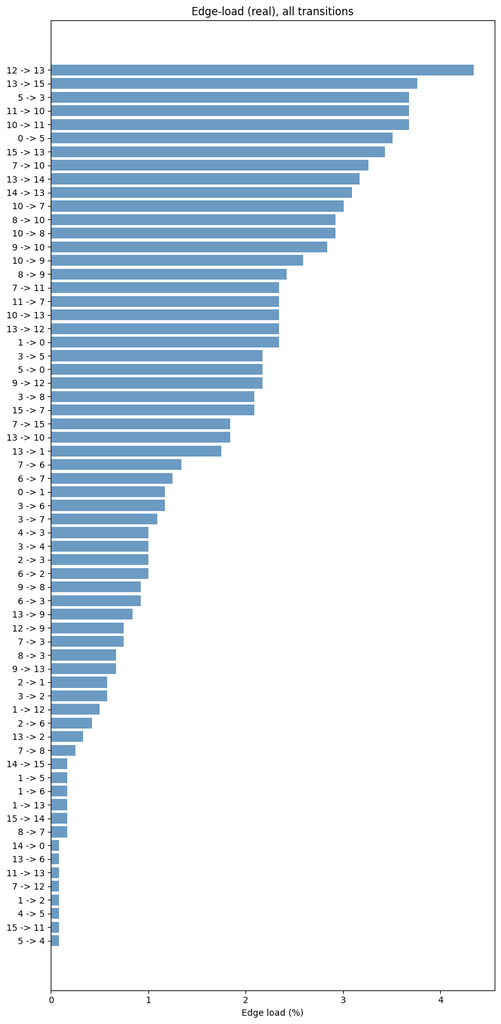

```python
polygons_with_zone, zone_labels, df_trans_real, total_real = load_edge_load_real(
    PATH_DXF, LAYER_AREA, PATH_TRAJECTORIES_CSV
)
```

## Edge-load (simulated)

Same for simulated tracks. Transition pattern in simulation should resemble real.

```
Edge-load (simulated), total transitions: 1727
n_edges (unique transitions): 45
dependency_pct: min=0.06, max=5.73, mean=2.22, median=2.32, std=1.74
count: min=1, max=99, mean=38.38, median=40.00, std=30.09
```

|  | from_zone | to_zone | count | dependency | dependency_pct |
| --- | --- | --- | --- | --- | --- |
| 0 | 0 | 1 | 7 | 0.004053 | 0.41 |
| 1 | 0 | 5 | 62 | 0.035900 | 3.59 |
| 2 | 1 | 0 | 7 | 0.004053 | 0.41 |
| 3 | 2 | 3 | 3 | 0.001737 | 0.17 |
| 4 | 2 | 6 | 6 | 0.003474 | 0.35 |
| 5 | 3 | 2 | 9 | 0.005211 | 0.52 |
| 6 | 3 | 5 | 11 | 0.006369 | 0.64 |
| 7 | 3 | 6 | 1 | 0.000579 | 0.06 |
| 8 | 3 | 7 | 35 | 0.020266 | 2.03 |
| 9 | 3 | 8 | 13 | 0.007528 | 0.75 |
| 10 | 5 | 0 | 11 | 0.006369 | 0.64 |
| 11 | 5 | 3 | 62 | 0.035900 | 3.59 |
| 12 | 6 | 3 | 3 | 0.001737 | 0.17 |
| 13 | 6 | 7 | 3 | 0.001737 | 0.17 |
| 14 | 7 | 3 | 1 | 0.000579 | 0.06 |
| 15 | 7 | 6 | 13 | 0.007528 | 0.75 |
| 16 | 7 | 8 | 2 | 0.001158 | 0.12 |
| 17 | 7 | 10 | 61 | 0.035321 | 3.53 |
| 18 | 7 | 11 | 58 | 0.033584 | 3.36 |
| 19 | 7 | 15 | 81 | 0.046902 | 4.69 |
| 20 | 8 | 9 | 24 | 0.013897 | 1.39 |
| 21 | 8 | 10 | 43 | 0.024899 | 2.49 |
| 22 | 9 | 8 | 13 | 0.007528 | 0.75 |
| 23 | 9 | 10 | 60 | 0.034742 | 3.47 |
| 24 | 9 | 12 | 24 | 0.013897 | 1.39 |
| 25 | 9 | 13 | 54 | 0.031268 | 3.13 |
| 26 | 10 | 7 | 40 | 0.023162 | 2.32 |
| 27 | 10 | 8 | 39 | 0.022583 | 2.26 |
| 28 | 10 | 9 | 59 | 0.034163 | 3.42 |
| 29 | 10 | 11 | 99 | 0.057325 | 5.73 |
| 30 | 10 | 13 | 67 | 0.038796 | 3.88 |
| 31 | 11 | 7 | 73 | 0.042270 | 4.23 |
| 32 | 11 | 10 | 84 | 0.048639 | 4.86 |
| 33 | 11 | 13 | 1 | 0.000579 | 0.06 |
| 34 | 12 | 9 | 18 | 0.010423 | 1.04 |
| 35 | 12 | 13 | 51 | 0.029531 | 2.95 |
| 36 | 13 | 9 | 50 | 0.028952 | 2.90 |
| 37 | 13 | 10 | 56 | 0.032426 | 3.24 |
| 38 | 13 | 11 | 1 | 0.000579 | 0.06 |
| 39 | 13 | 12 | 45 | 0.026057 | 2.61 |
| 40 | 13 | 14 | 67 | 0.038796 | 3.88 |
| 41 | 13 | 15 | 81 | 0.046902 | 4.69 |
| 42 | 14 | 13 | 67 | 0.038796 | 3.88 |
| 43 | 15 | 7 | 65 | 0.037638 | 3.76 |
| 44 | 15 | 13 | 97 | 0.056167 | 5.62 |

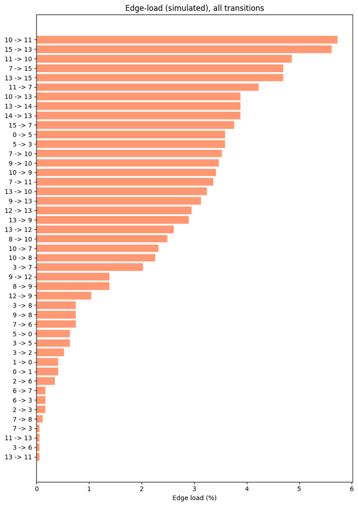

```python
df_trans_sim, total_sim = load_edge_load_sim(
    PATH_DXF, PATH_UNITY_DXF, LAYER_UNITY_TRACKS, polygons_with_zone, zone_labels
)
```

## Edge-load comparison

Scatter: dependency_pct real vs simulated by transition. Closeness to y=x diagonal means similar pattern.

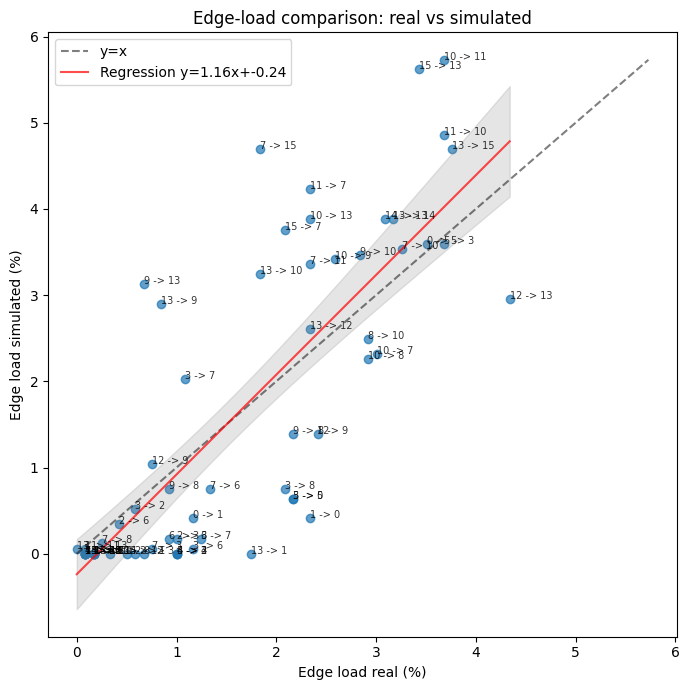

```
--- Basic edge-load stats ---
pct_real:  mean=1.5148, std=1.2338, min=0.0000, max=4.3400
pct_sim:   mean=1.5155, std=1.7591, min=0.0000, max=5.7300
count_real: mean=18.14, std=14.76, min=0, max=52
count_sim:  mean=26.17, std=30.38, min=0, max=99
--- Edge-load correlation and comparison metrics ---
dependency_pct: Pearson=0.8116, Spearman=0.8300
dependency_pct: MAE=0.7906, RMSE=1.0458
count: Pearson=0.8111, Spearman=0.8300
count: MAE=15.09
```

```python
# Fallback: load simulation from DXF if not already run
try:
    from room_popularity import load_simulated_trajectories_from_unity_dxf, parse_zones_from_dxf, compute_transition_matrix
except ImportError:
    pass
if "traj_sim" not in globals() or len(traj_sim) == 0:
    traj_sim = load_simulated_trajectories_from_unity_dxf(PATH_DXF, PATH_UNITY_DXF, layer_reference_bird="Outline", layer_tracks_unity=LAYER_UNITY_TRACKS)
if "polygons_with_zone" not in globals() or "zone_labels" not in globals():
    polygons_with_zone, zone_labels = parse_zones_from_dxf(PATH_DXF, LAYER_AREA)
if len(traj_sim) > 0 and ("df_trans_sim" not in globals() or "total_sim" not in globals()):
    df_trans_sim, total_sim = compute_transition_matrix(polygons_with_zone, zone_labels, traj_sim)

have_sim = len(traj_sim) > 0 and "total_sim" in globals() and total_sim > 0
if have_sim:
    run_edge_load_comparison(df_trans_real, df_trans_sim)
else:
    print("No simulated tracks for edge-load comparison.")
```

### Global summary (macro)

Summary of real vs simulated comparison for **Room popularity** and **Edge-load**, with targets and recommendations.

```python
# Global summary (macro): room popularity + edge-load (run after all comparison cells above)
from IPython.display import display, Markdown
display(Markdown(run_global_summary_macro(df_real, df_sim, n_traj_sim, df_trans_real, df_trans_sim)))
```

Global summary: real vs simulated (macro)

Room popularity

- **Pearson (n_agents):** r = 0.765 — linear agreement on visit counts per zone.

- **Spearman (rank):** rho = 0.907 — **strong** agreement on zone ranking.

- **Target:** Spearman (rank) ≥ 0.7 ✓.

Edge-load

- **dependency_pct:** Pearson r = 0.812, Spearman rho = 0.830 — **strong** agreement.

- **count:** Pearson r = 0.811, Spearman rho = 0.830. MAE(pct) = 0.791.

- **Target:** Spearman (dependency_pct) ≥ 0.7 ✓.

Recommendations (targets to aim for)

- **Room popularity:** Spearman rank correlation ≥ 0.7 indicates good agreement on which zones are most/least visited. Pearson on n_agents reflects similarity in absolute counts.

- **Edge-load:** Spearman ≥ 0.7 on dependency_pct (or count) indicates that transition flows between zones match well. Lower MAE on dependency_pct is better.

*Summary generated from metrics computed in the cells above.*